# Statical Analysis on Tooth Growth of Guinea Pigs

Bamidele Tella

8/27/2020

# OVERVIEW

This is the part 2 of the final project from Coursera’s statistical inference course. In this project, we perform inferential analysis on one of the data in R dataset named ToothGrowth. At the end of the analysis, we shall see the relation of between the length of tooth of guinea pigs and supplements given. The dosage effect would also be considered.

# ANALYSIS

## Loading Packages

First, we load the packages need to perform analysis as well as the data set ToothGrowth.

```r
library(ggplot2)
library(datasets)
data(ToothGrowth)
```

## Summary of Data

```r
head(ToothGrowth)
```

|  | len | supp | dose |
| --- | --- | --- | --- |
| 1 | 4.2 | VC | 0.5 |
| 2 | 11.5 | VC | 0.5 |
| 3 | 7.3 | VC | 0.5 |
| 4 | 5.8 | VC | 0.5 |
| 5 | 6.4 | VC | 0.5 |
| 6 | 10.0 | VC | 0.5 |

```r
summary(ToothGrowth)
```

```
##       len        supp         dose
##  Min.   : 4.20   OJ:30   Min.   :0.500
##  1st Qu.:13.07   VC:30   1st Qu.:0.500
##  Median :19.25           Median :1.000
##  Mean   :18.81           Mean   :1.167
##  3rd Qu.:25.27           3rd Qu.:2.000
##  Max.   :33.90           Max.   :2.000
```

```r
ToothGrowth$dose<-as.factor(ToothGrowth$dose)
str(ToothGrowth)
```

```
## 'data.frame':    60 obs. of  3 variables:
##  $ len : num  4.2 11.5 7.3 5.8 6.4 10 11.2 11.2 5.2 7 ...
##  $ supp: Factor w/ 2 levels "OJ","VC": 2 2 2 2 2 2 2 2 2 2 ...
##  $ dose: Factor w/ 3 levels "0.5","1","2": 1 1 1 1 1 1 1 1 1 1 ...
```

## Exploratory Analysis

Now, we visualise the data to get a more detailed idea of the relationship.

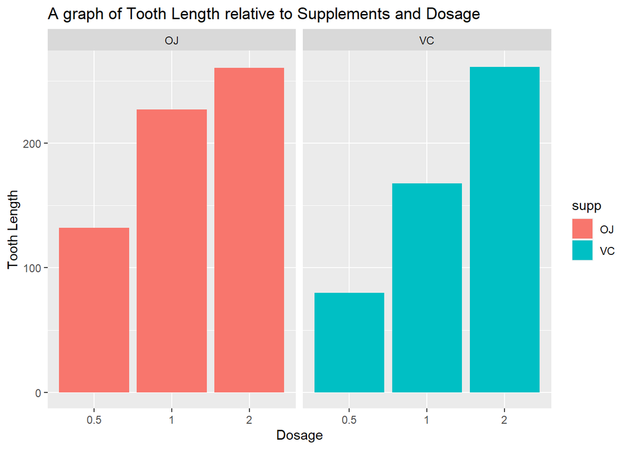

```r
gtooth <-ggplot(ToothGrowth,aes(x=dose, y=len, fill=supp))
gtooth <- gtooth + geom_bar(stat = "identity") + facet_grid(.~supp)
gtooth <- gtooth + labs(title = "A graph of Tooth Length relative to Supplements and Dosage",x="Dosage",y="Tooth Length")
gtooth
```

## T-Test

### Tooth Length relative to Supplements given.

First, we take the t test of tooth length relative to supplements types.

```r
t.test(len~supp,data=ToothGrowth, paired = F,var.equal=F)
```

```
##
##  Welch Two Sample t-test
##
## data:  len by supp
## t = 1.9153, df = 55.309, p-value = 0.06063
## alternative hypothesis: true difference in means is not equal to 0
## 95 percent confidence interval:
##  -0.1710156  7.5710156
## sample estimates:
## mean in group OJ mean in group VC
##         20.66333         16.96333
```

From our t test analysis, we see that we have a p value of 0.06 which is above the 5% and confidence interval contains zero(0). This implies that we fail to reject our hypothesis.

### Tooth Length relative to different Dosage Administered

Next, we take a t test analysis of the Tooth Length relative to each of the three different dosage given.

```r
dose1<-subset(ToothGrowth,dose %in% c(0.5,1))
dose2<- subset(ToothGrowth,dose %in% c(0.5,2.0))
dose3<- subset(ToothGrowth,dose %in% c(1.0,2.0))
t.test(len~dose,data = dose1, paired=F,var.equal=F)
```

```
##
##  Welch Two Sample t-test
##
## data:  len by dose
## t = -6.4766, df = 37.986, p-value = 1.268e-07
## alternative hypothesis: true difference in means is not equal to 0
## 95 percent confidence interval:
##  -11.983781  -6.276219
## sample estimates:
## mean in group 0.5   mean in group 1
##            10.605            19.735
```

```r
t.test(len~dose,data = dose2, paired=F,var.equal=F)
```

```
##
##  Welch Two Sample t-test
##
## data:  len by dose
## t = -11.799, df = 36.883, p-value = 4.398e-14
## alternative hypothesis: true difference in means is not equal to 0
## 95 percent confidence interval:
##  -18.15617 -12.83383
## sample estimates:
## mean in group 0.5   mean in group 2
##            10.605            26.100
```

```r
t.test(len~dose,data = dose3, paired=F,var.equal=F)
```

```
##
##  Welch Two Sample t-test
##
## data:  len by dose
## t = -4.9005, df = 37.101, p-value = 1.906e-05
## alternative hypothesis: true difference in means is not equal to 0
## 95 percent confidence interval:
##  -8.996481 -3.733519
## sample estimates:
## mean in group 1 mean in group 2
##          19.735          26.100
```

As analysed above, we see that each dosage analysis relative to length has a p value of approximately zero(0) which is less than the 5% level with non-zero(0) confidence levels. Therefore we reject the hypothesis due to the low p value.

# Assumption

We assume that the supplements administered has no effect on the growth length of the tooth of guinea pigs.

# Conclusion